# Practical Machine Learning Course Project

Ryan Sanders

9/21/2018

## Getting the data

First let’s download the training and testing datasets, if they haven’t been downloaded already.

```r
# Check directory doesn't exist and create if not
if (!file.exists("data")) {
    dir.create("data")
}

if (!file.exists("data/pml-training.csv")) {
    fileUrl <- "https://d396qusza40orc.cloudfront.net/predmachlearn/pml-training.csv"
    download.file(fileUrl, destfile = "data/pml-training.csv")
}

if (!file.exists("data/pml-testing.csv")) {
    fileUrl <- "https://d396qusza40orc.cloudfront.net/predmachlearn/pml-testing.csv"
    download.file(fileUrl, destfile = "data/pml-testing.csv")
}
```

## Load, explore and clean the training data

To start with let’s look for columns that are unlikely to be predictors, eg, a record ID, or the name of the participant. These can be removed from the data to be used in training the model.

```r
data.training <-
    read.csv(
        "data/pml-training.csv",
        stringsAsFactors = FALSE,
        na.strings = c("#DIV/0!", "NA", "")
    )

# Classe (how well the activity was performed) should be a factor
data.training$classe <- factor(data.training$classe)

names(data.training)
```

```
##   [1] "X"                        "user_name"
##   [3] "raw_timestamp_part_1"     "raw_timestamp_part_2"
##   [5] "cvtd_timestamp"           "new_window"
##   [7] "num_window"               "roll_belt"
##   [9] "pitch_belt"               "yaw_belt"
##  [11] "total_accel_belt"         "kurtosis_roll_belt"
##  [13] "kurtosis_picth_belt"      "kurtosis_yaw_belt"
##  [15] "skewness_roll_belt"       "skewness_roll_belt.1"
##  [17] "skewness_yaw_belt"        "max_roll_belt"
##  [19] "max_picth_belt"           "max_yaw_belt"
##  [21] "min_roll_belt"            "min_pitch_belt"
##  [23] "min_yaw_belt"             "amplitude_roll_belt"
##  [25] "amplitude_pitch_belt"     "amplitude_yaw_belt"
##  [27] "var_total_accel_belt"     "avg_roll_belt"
##  [29] "stddev_roll_belt"         "var_roll_belt"
```

[output cut: 65 more lines]

```r
data.training %>%
    select(X:num_window) %>%
    head
```

```
##   X user_name raw_timestamp_part_1 raw_timestamp_part_2   cvtd_timestamp
## 1 1  carlitos           1323084231               788290 05/12/2011 11:23
## 2 2  carlitos           1323084231               808298 05/12/2011 11:23
## 3 3  carlitos           1323084231               820366 05/12/2011 11:23
## 4 4  carlitos           1323084232               120339 05/12/2011 11:23
## 5 5  carlitos           1323084232               196328 05/12/2011 11:23
## 6 6  carlitos           1323084232               304277 05/12/2011 11:23
##   new_window num_window
## 1         no         11
## 2         no         11
## 3         no         11
## 4         no         12
## 5         no         12
## 6         no         12
```

```r
subset.data.training <- data.training %>%
    select(-(X:num_window))
```

Next, let’s look at missing data. There seem to be columns where either all or the vast majority of the rows are NAs. The following confirms this, and removes those columns since imputing from the small number of rows with data isn’t likely to yield much of value.

```r
subset.data.training %>%
    summarize_all(funs(sum(is.na(.)) / n())) %>%
    select_if(function(col) col > 0)
```

```
##   kurtosis_roll_belt kurtosis_picth_belt kurtosis_yaw_belt
## 1          0.9798186           0.9809398                 1
##   skewness_roll_belt skewness_roll_belt.1 skewness_yaw_belt max_roll_belt
## 1          0.9797676            0.9809398                 1     0.9793089
##   max_picth_belt max_yaw_belt min_roll_belt min_pitch_belt min_yaw_belt
## 1      0.9793089    0.9798186     0.9793089      0.9793089    0.9798186
##   amplitude_roll_belt amplitude_pitch_belt amplitude_yaw_belt
## 1           0.9793089            0.9793089          0.9798186
##   var_total_accel_belt avg_roll_belt stddev_roll_belt var_roll_belt
## 1            0.9793089     0.9793089        0.9793089     0.9793089
##   avg_pitch_belt stddev_pitch_belt var_pitch_belt avg_yaw_belt
## 1      0.9793089         0.9793089      0.9793089    0.9793089
##   stddev_yaw_belt var_yaw_belt var_accel_arm avg_roll_arm stddev_roll_arm
## 1       0.9793089    0.9793089     0.9793089    0.9793089       0.9793089
##   var_roll_arm avg_pitch_arm stddev_pitch_arm var_pitch_arm avg_yaw_arm
## 1    0.9793089     0.9793089        0.9793089     0.9793089   0.9793089
##   stddev_yaw_arm var_yaw_arm kurtosis_roll_arm kurtosis_picth_arm
## 1      0.9793089   0.9793089         0.9832841           0.983386
##   kurtosis_yaw_arm skewness_roll_arm skewness_pitch_arm skewness_yaw_arm
## 1        0.9798695         0.9832331           0.983386        0.9798695
##   max_roll_arm max_picth_arm max_yaw_arm min_roll_arm min_pitch_arm
## 1    0.9793089     0.9793089   0.9793089    0.9793089     0.9793089
##   min_yaw_arm amplitude_roll_arm amplitude_pitch_arm amplitude_yaw_arm
## 1   0.9793089          0.9793089           0.9793089         0.9793089
##   kurtosis_roll_dumbbell kurtosis_picth_dumbbell kurtosis_yaw_dumbbell
## 1              0.9795638               0.9794109                     1
##   skewness_roll_dumbbell skewness_pitch_dumbbell skewness_yaw_dumbbell
## 1              0.9795128               0.9793599                     1
##   max_roll_dumbbell max_picth_dumbbell max_yaw_dumbbell min_roll_dumbbell
## 1         0.9793089          0.9793089        0.9795638         0.9793089
##   min_pitch_dumbbell min_yaw_dumbbell amplitude_roll_dumbbell
## 1          0.9793089        0.9795638               0.9793089
##   amplitude_pitch_dumbbell amplitude_yaw_dumbbell var_accel_dumbbell
## 1                0.9793089              0.9795638          0.9793089
##   avg_roll_dumbbell stddev_roll_dumbbell var_roll_dumbbell
## 1         0.9793089            0.9793089         0.9793089
##   avg_pitch_dumbbell stddev_pitch_dumbbell var_pitch_dumbbell
## 1          0.9793089             0.9793089          0.9793089
##   avg_yaw_dumbbell stddev_yaw_dumbbell var_yaw_dumbbell
## 1        0.9793089           0.9793089        0.9793089
##   kurtosis_roll_forearm kurtosis_picth_forearm kurtosis_yaw_forearm
## 1             0.9835898              0.9836408                    1
##   skewness_roll_forearm skewness_pitch_forearm skewness_yaw_forearm
## 1             0.9835389              0.9836408                    1
##   max_roll_forearm max_picth_forearm max_yaw_forearm min_roll_forearm
## 1        0.9793089         0.9793089       0.9835898        0.9793089
##   min_pitch_forearm min_yaw_forearm amplitude_roll_forearm
## 1         0.9793089       0.9835898              0.9793089
##   amplitude_pitch_forearm amplitude_yaw_forearm var_accel_forearm
## 1               0.9793089             0.9835898         0.9793089
##   avg_roll_forearm stddev_roll_forearm var_roll_forearm avg_pitch_forearm
## 1        0.9793089           0.9793089        0.9793089         0.9793089
##   stddev_pitch_forearm var_pitch_forearm avg_yaw_forearm
## 1            0.9793089         0.9793089       0.9793089
##   stddev_yaw_forearm var_yaw_forearm
## 1          0.9793089       0.9793089
```

```r
not_mostly_na <- function(x) {
    sum(is.na(x)) == 0
}

subset.data.training <- subset.data.training %>%
    select_if(not_mostly_na)
```

Let’s take another look at the data to confirm things look better now and check for highly correlated predictors.

```r
summary(subset.data.training)
```

```
##    roll_belt        pitch_belt          yaw_belt       total_accel_belt
##  Min.   :-28.90   Min.   :-55.8000   Min.   :-180.00   Min.   : 0.00
##  1st Qu.:  1.10   1st Qu.:  1.7600   1st Qu.: -88.30   1st Qu.: 3.00
##  Median :113.00   Median :  5.2800   Median : -13.00   Median :17.00
##  Mean   : 64.41   Mean   :  0.3053   Mean   : -11.21   Mean   :11.31
##  3rd Qu.:123.00   3rd Qu.: 14.9000   3rd Qu.:  12.90   3rd Qu.:18.00
##  Max.   :162.00   Max.   : 60.3000   Max.   : 179.00   Max.   :29.00
##   gyros_belt_x        gyros_belt_y       gyros_belt_z
##  Min.   :-1.040000   Min.   :-0.64000   Min.   :-1.4600
##  1st Qu.:-0.030000   1st Qu.: 0.00000   1st Qu.:-0.2000
##  Median : 0.030000   Median : 0.02000   Median :-0.1000
##  Mean   :-0.005592   Mean   : 0.03959   Mean   :-0.1305
##  3rd Qu.: 0.110000   3rd Qu.: 0.11000   3rd Qu.:-0.0200
##  Max.   : 2.220000   Max.   : 0.64000   Max.   : 1.6200
##   accel_belt_x       accel_belt_y     accel_belt_z     magnet_belt_x
##  Min.   :-120.000   Min.   :-69.00   Min.   :-275.00   Min.   :-52.0
##  1st Qu.: -21.000   1st Qu.:  3.00   1st Qu.:-162.00   1st Qu.:  9.0
##  Median : -15.000   Median : 35.00   Median :-152.00   Median : 35.0
##  Mean   :  -5.595   Mean   : 30.15   Mean   : -72.59   Mean   : 55.6
##  3rd Qu.:  -5.000   3rd Qu.: 61.00   3rd Qu.:  27.00   3rd Qu.: 59.0
##  Max.   :  85.000   Max.   :164.00   Max.   : 105.00   Max.   :485.0
##  magnet_belt_y   magnet_belt_z       roll_arm         pitch_arm
##  Min.   :354.0   Min.   :-623.0   Min.   :-180.00   Min.   :-88.800
##  1st Qu.:581.0   1st Qu.:-375.0   1st Qu.: -31.77   1st Qu.:-25.900
##  Median :601.0   Median :-320.0   Median :   0.00   Median :  0.000
##  Mean   :593.7   Mean   :-345.5   Mean   :  17.83   Mean   : -4.612
##  3rd Qu.:610.0   3rd Qu.:-306.0   3rd Qu.:  77.30   3rd Qu.: 11.200
##  Max.   :673.0   Max.   : 293.0   Max.   : 180.00   Max.   : 88.500
##     yaw_arm          total_accel_arm  gyros_arm_x        gyros_arm_y
##  Min.   :-180.0000   Min.   : 1.00   Min.   :-6.37000   Min.   :-3.4400
##  1st Qu.: -43.1000   1st Qu.:17.00   1st Qu.:-1.33000   1st Qu.:-0.8000
##  Median :   0.0000   Median :27.00   Median : 0.08000   Median :-0.2400
##  Mean   :  -0.6188   Mean   :25.51   Mean   : 0.04277   Mean   :-0.2571
##  3rd Qu.:  45.8750   3rd Qu.:33.00   3rd Qu.: 1.57000   3rd Qu.: 0.1400
##  Max.   : 180.0000   Max.   :66.00   Max.   : 4.87000   Max.   : 2.8400
##   gyros_arm_z       accel_arm_x       accel_arm_y      accel_arm_z
##  Min.   :-2.3300   Min.   :-404.00   Min.   :-318.0   Min.   :-636.00
##  1st Qu.:-0.0700   1st Qu.:-242.00   1st Qu.: -54.0   1st Qu.:-143.00
##  Median : 0.2300   Median : -44.00   Median :  14.0   Median : -47.00
##  Mean   : 0.2695   Mean   : -60.24   Mean   :  32.6   Mean   : -71.25
```

[output cut: 50 more lines]

```
##  Max.   :311.00000   Max.   :231.0000   Max.   : 477.00   Max.   : 923.0
##  accel_forearm_z   magnet_forearm_x  magnet_forearm_y magnet_forearm_z
##  Min.   :-446.00   Min.   :-1280.0   Min.   :-896.0   Min.   :-973.0
##  1st Qu.:-182.00   1st Qu.: -616.0   1st Qu.:   2.0   1st Qu.: 191.0
##  Median : -39.00   Median : -378.0   Median : 591.0   Median : 511.0
##  Mean   : -55.29   Mean   : -312.6   Mean   : 380.1   Mean   : 393.6
##  3rd Qu.:  26.00   3rd Qu.:  -73.0   3rd Qu.: 737.0   3rd Qu.: 653.0
##  Max.   : 291.00   Max.   :  672.0   Max.   :1480.0   Max.   :1090.0
##  classe
##  A:5580
##  B:3797
##  C:3422
##  D:3216
##  E:3607
##
```

```r
z <- cor(subset.data.training[, -53])
# This will leave duplicates (eg, X, Y will also show as Y, X)
as.tibble(as.table(z)) %>%
    filter(Var1 != Var2) %>%
    arrange(desc(n)) %>%
    filter(n > 0.8)
```

```
## # A tibble: 22 x 3
##    Var1             Var2                 n
##    <chr>            <chr>            <dbl>
##  1 total_accel_belt roll_belt        0.981
##  2 roll_belt        total_accel_belt 0.981
##  3 gyros_forearm_z  gyros_dumbbell_z 0.933
##  4 gyros_dumbbell_z gyros_forearm_z  0.933
##  5 accel_belt_y     total_accel_belt 0.928
##  6 total_accel_belt accel_belt_y     0.928
##  7 accel_belt_y     roll_belt        0.925
##  8 roll_belt        accel_belt_y     0.925
##  9 magnet_belt_x    accel_belt_x     0.892
## 10 accel_belt_x     magnet_belt_x    0.892
## # ... with 12 more rows
```

So there are definitely some highly (linearly) correlated predictors. For now, I’m going to ignore those but it should be noted that any model could probably be created with a more parsimonious set of predictors.

## Selecting a model

This is a classification problem. There are three models I’d like to try:

1. k-nearest neighbors (k-NN)
2. Decision tree
3. Random forest

There are other models that could be considered, eg, a neural network, but let’s see how well the above three do.

For every model I plan to use ten-fold cross validation. For model evaluation, I plan on using accuracy as the critical metric.

### k-NN

Starting with k-NN, the summary of the data above shows a wide range of values for different predictors. As k-NN uses distance between predictors I’m centering and scaling the predictors so they are consistent. I’m going to consider k set from 1 to 10 inclusive to see what works best; potentially will need to consider larger values of k in a second iteration.

```r
set.seed(123)
trControl <- trainControl(method = "cv", number = 10)
modelFit.knn <-
    train(
        classe ~ .,
        data = subset.data.training,
        method = "knn",
        tuneGrid = expand.grid(k = 1:10),
        trControl = trControl,
        preProcess = c("center", "scale")
    )

modelFit.knn
```

```
## k-Nearest Neighbors
##
## 19622 samples
##    52 predictor
##     5 classes: 'A', 'B', 'C', 'D', 'E'
##
## Pre-processing: centered (52), scaled (52)
## Resampling: Cross-Validated (10 fold)
## Summary of sample sizes: 17660, 17660, 17658, 17660, 17659, 17660, ...
## Resampling results across tuning parameters:
##
##   k   Accuracy   Kappa
##    1  0.9939862  0.9923931
##    2  0.9874629  0.9841428
##    3  0.9860868  0.9824012
##    4  0.9791051  0.9735684
##    5  0.9764041  0.9701497
##    6  0.9695241  0.9614436
##    7  0.9681480  0.9597012
##    8  0.9627973  0.9529297
##    9  0.9590262  0.9481544
##   10  0.9539301  0.9417061
##
## Accuracy was used to select the optimal model using the largest value.
## The final value used for the model was k = 1.
```

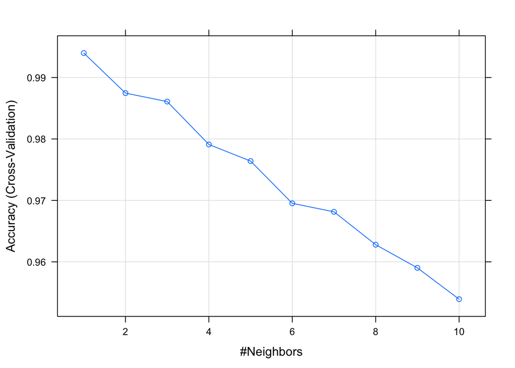

```r
plot(modelFit.knn)
```

```r
confusionMatrix(subset.data.training$classe,
                predict(modelFit.knn, subset.data.training))
```

```
## Confusion Matrix and Statistics
##
##           Reference
## Prediction    A    B    C    D    E
##          A 5580    0    0    0    0
##          B    0 3797    0    0    0
##          C    0    0 3422    0    0
##          D    0    0    0 3216    0
##          E    0    0    0    0 3607
##
## Overall Statistics
##
##                Accuracy : 1
##                  95% CI : (0.9998, 1)
##     No Information Rate : 0.2844
##     P-Value [Acc > NIR] : < 2.2e-16
##
##                   Kappa : 1
##  Mcnemar's Test P-Value : NA
##
## Statistics by Class:
##
##                      Class: A Class: B Class: C Class: D Class: E
## Sensitivity            1.0000   1.0000   1.0000   1.0000   1.0000
## Specificity            1.0000   1.0000   1.0000   1.0000   1.0000
## Pos Pred Value         1.0000   1.0000   1.0000   1.0000   1.0000
## Neg Pred Value         1.0000   1.0000   1.0000   1.0000   1.0000
## Prevalence             0.2844   0.1935   0.1744   0.1639   0.1838
## Detection Rate         0.2844   0.1935   0.1744   0.1639   0.1838
## Detection Prevalence   0.2844   0.1935   0.1744   0.1639   0.1838
## Balanced Accuracy      1.0000   1.0000   1.0000   1.0000   1.0000
```

The best model has k = 1 and an accuracy of ~ 0.9940. This predicts the entire training data set perfectly, albeit with the risk of the model being overfit. As training was done using cross validation, 0.9940 is the estimate for the out of sample error.

### Decision tree

```r
set.seed(123)
modelFit.rpart <-
    train(classe ~ .,
          data = subset.data.training,
          method = "rpart",
          trControl = trControl)

modelFit.rpart
```

```
## CART
##
## 19622 samples
##    52 predictor
##     5 classes: 'A', 'B', 'C', 'D', 'E'
##
## No pre-processing
## Resampling: Cross-Validated (10 fold)
## Summary of sample sizes: 17660, 17660, 17658, 17660, 17659, 17660, ...
## Resampling results across tuning parameters:
##
##   cp          Accuracy   Kappa
##   0.03567868  0.5056580  0.35438893
##   0.05998671  0.4422679  0.25192620
##   0.11515454  0.3230481  0.05895743
##
## Accuracy was used to select the optimal model using the largest value.
## The final value used for the model was cp = 0.03567868.
```

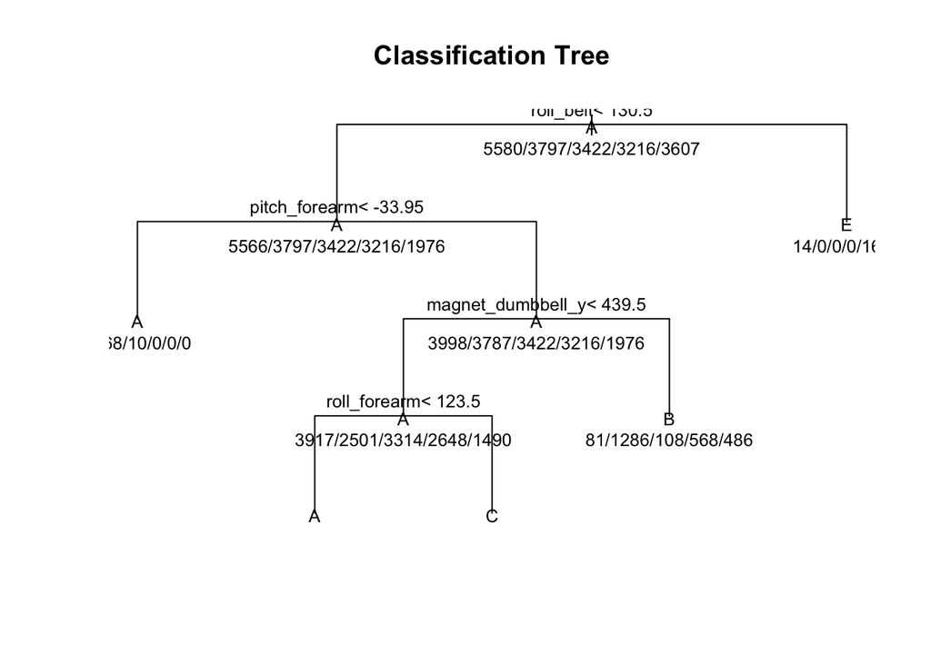

```r
plot(modelFit.rpart$finalModel, uniform = TRUE,
     main = "Classification Tree")
text(modelFit.rpart$finalModel,
     use.n = TRUE,
     all = TRUE,
     cex = .8)
```

```r
confusionMatrix(subset.data.training$classe,
                predict(modelFit.rpart, subset.data.training))
```

```
## Confusion Matrix and Statistics
##
##           Reference
## Prediction    A    B    C    D    E
##          A 5080   81  405    0   14
##          B 1581 1286  930    0    0
##          C 1587  108 1727    0    0
##          D 1449  568 1199    0    0
##          E  524  486  966    0 1631
##
## Overall Statistics
##
##                Accuracy : 0.4956
##                  95% CI : (0.4885, 0.5026)
##     No Information Rate : 0.5209
##     P-Value [Acc > NIR] : 1
##
##                   Kappa : 0.3407
##  Mcnemar's Test P-Value : NA
##
## Statistics by Class:
##
##                      Class: A Class: B Class: C Class: D Class: E
## Sensitivity            0.4970  0.50850  0.33040       NA  0.99149
## Specificity            0.9468  0.85310  0.88225   0.8361  0.89008
## Pos Pred Value         0.9104  0.33869  0.50468       NA  0.45218
## Neg Pred Value         0.6339  0.92145  0.78395       NA  0.99913
## Prevalence             0.5209  0.12889  0.26638   0.0000  0.08383
## Detection Rate         0.2589  0.06554  0.08801   0.0000  0.08312
## Detection Prevalence   0.2844  0.19351  0.17440   0.1639  0.18382
## Balanced Accuracy      0.7219  0.68080  0.60633       NA  0.94079
```

The decision tree does poorly. It never predicts a classe of D and has an accuracy of ~ 0.5057. As training was done using cross validation, 0.5057 is the estimate for the out of sample error.

### Random forest

```r
set.seed(123)
modelFit.rf <-
    train(classe ~ .,
          data = subset.data.training,
          method = "rf",
          trControl = trControl)

modelFit.rf
```

```
## Random Forest
##
## 19622 samples
##    52 predictor
##     5 classes: 'A', 'B', 'C', 'D', 'E'
##
## No pre-processing
## Resampling: Cross-Validated (10 fold)
## Summary of sample sizes: 17660, 17660, 17658, 17660, 17659, 17660, ...
## Resampling results across tuning parameters:
##
##   mtry  Accuracy   Kappa
##    2    0.9954645  0.9942627
##   27    0.9949545  0.9936176
##   52    0.9896544  0.9869116
##
## Accuracy was used to select the optimal model using the largest value.
## The final value used for the model was mtry = 2.
```

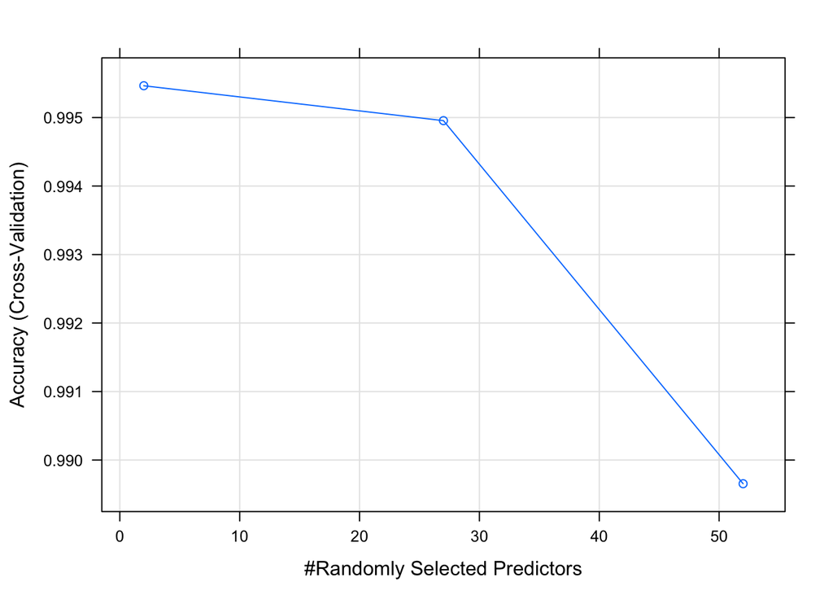

```r
plot(modelFit.rf)
```

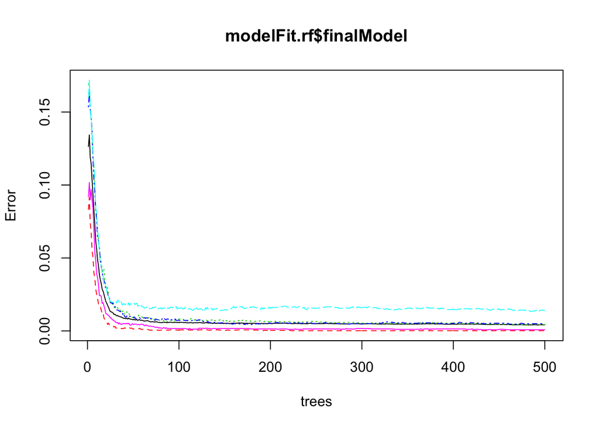

```r
plot(modelFit.rf$finalModel)
```

```r
confusionMatrix(subset.data.training$classe,
                predict(modelFit.rf, subset.data.training))
```

```
## Confusion Matrix and Statistics
##
##           Reference
## Prediction    A    B    C    D    E
##          A 5580    0    0    0    0
##          B    0 3797    0    0    0
##          C    0    0 3422    0    0
##          D    0    0    0 3216    0
##          E    0    0    0    0 3607
##
## Overall Statistics
##
##                Accuracy : 1
##                  95% CI : (0.9998, 1)
##     No Information Rate : 0.2844
##     P-Value [Acc > NIR] : < 2.2e-16
##
##                   Kappa : 1
##  Mcnemar's Test P-Value : NA
##
## Statistics by Class:
##
##                      Class: A Class: B Class: C Class: D Class: E
## Sensitivity            1.0000   1.0000   1.0000   1.0000   1.0000
## Specificity            1.0000   1.0000   1.0000   1.0000   1.0000
## Pos Pred Value         1.0000   1.0000   1.0000   1.0000   1.0000
## Neg Pred Value         1.0000   1.0000   1.0000   1.0000   1.0000
## Prevalence             0.2844   0.1935   0.1744   0.1639   0.1838
## Detection Rate         0.2844   0.1935   0.1744   0.1639   0.1838
## Detection Prevalence   0.2844   0.1935   0.1744   0.1639   0.1838
## Balanced Accuracy      1.0000   1.0000   1.0000   1.0000   1.0000
```

Random forest does better than k-NN. Accuracy is 0.9955 and it also predicts the entire training set perfectly. As training was done using cross validation, 0.9955 is the estimate for the out of sample error.

## Selecting a model for prediction

I stated above that accuracy would be the metric used for selecting a model. On this basis, the random forest model does best. There’s no real benefit between the two contenders in terms of interpretability, neither being particularly interpretable, but that’s not really a major driver here (ie, pass the prediction test :-)).

Using the random forest model did result in 100% on the prediction test.

For reference, the testing data needs to be cleaned in the same way as the training data was.

```r
data.testing <-
    read.csv(
        "data/pml-testing.csv",
        stringsAsFactors = FALSE,
        na.strings = c("#DIV/0!", "NA", "")
    )

subset.data.testing <- data.testing %>%
    select(-(X:num_window))

subset.data.testing <- subset.data.testing %>%
    select_if(not_mostly_na)

#predict(modelFit.rf, subset.data.testing[, -53])
```

## Further progress

Potential next steps are:

1. Find a more parsimonious set of predictors to use in modeling and prediction.
2. Try some other models, eg, a neural net. This is probably of lesser importance given the accuracy achieved, but may make for an interesting comparison.